# Classification HW

Aaron

June 28, 2016

Please read chapter 4 of [Introduction to Statistical Learning](http://www-bcf.usc.edu/~gareth/ISL/index.html) in R.

```r
library(dplyr)
```

```r
library(ggplot2)
library(corrplot)
```

### 1

Example of confounding. Use mtcars and show confounding between any 2 of the variables

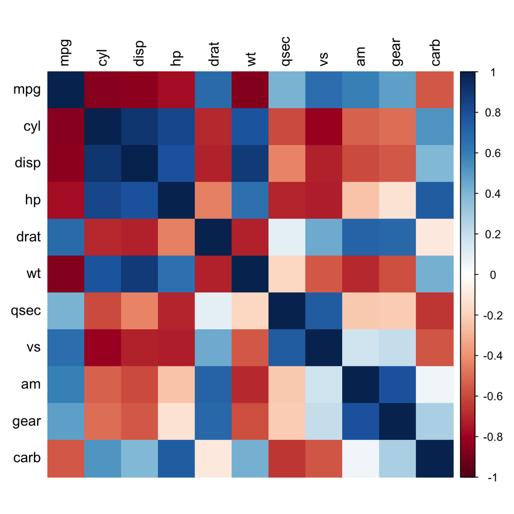

```r
data("mtcars")

mtcars %>%
    cor(.) %>%
    corrplot(method="color", tl.col="black")
```

Here we can see `wt` is highly negatively correlated with `am`

```r
names(mtcars)
```

```
##  [1] "mpg"  "cyl"  "disp" "hp"   "drat" "wt"   "qsec" "vs"   "am"   "gear"
## [11] "carb"
```

```r
mtcars %>%
    lm(mpg ~ am, .) %>%
    coef()
```

```
## (Intercept)          am
##   17.147368    7.244939
```

```r
mtcars %>%
    lm(mpg ~ wt + am, .) %>%
    coef()
```

```
## (Intercept)          wt          am
## 37.32155131 -5.35281145 -0.02361522
```

Notice the sign flip in `an`.

`wt` confound the relationship between `mpg` and `am`.

### 2

Give 3 reasons why LDA could perform better than logistic regression

- When the classes are well-separated, the parameter estimates for the logistic regression model are surprisingly unstable. Linear discrimi- nant analysis does not suffer from this problem.
- If *n* is small and the distribution of the predictors X is approximately normal in each of the classes, the linear discriminant model is again more stable than the logistic regression model.
- Linear discriminant analysis is popular when we have more than two response classes.

### 3

*Hint: see section 4.4.2*

- What is the theoretical error rate for LDA?

- Why is this true? (Hint: how does it compare to a Bayes Classifier)

The LDA classifier results from assuming that the observa- tions within each class come from a normal distribution with a class-specific mean vector and a common variance σ2, and plugging estimates for these parameters into the Bayes classifier.

### 4

Since real world data does not provide mu or sigma, how does LDA estimate them. *(hint: provide the formula for each and provide a 2 sentence description)*

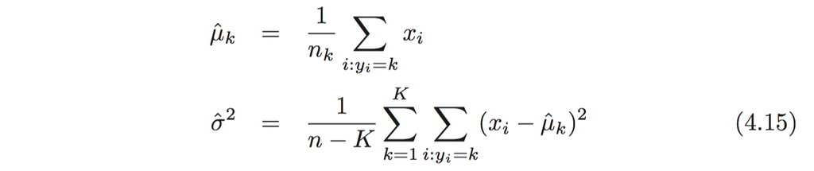

The estimate for μk is simply the average of all the training observations from the kth class, while σˆ2 can be seen as a weighted average of the sample variances for each of the K classes.

### 5

You will find a confusion matrix on page 145:

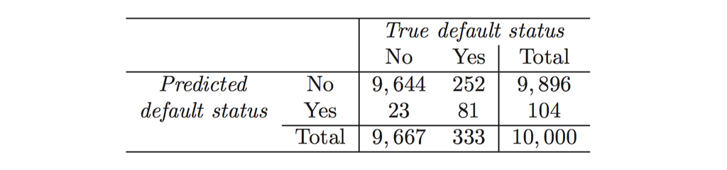

- What does the number 81 tell you?

> True Positives. There are 81 obs defaulted that were also predicted by the model.
- What does the number 23 tell you?

> False Positives. There are 23 obs didn’t default but predicted as default.
- What does the number 9896 tell you?

### 6

If the posterior probability of default is computed as 0.51 is a person classified as in the default class or not?

By default, yes, but that also has to be dependent on what threshold we decide to use.

### 7

How many people are incorrectly classified if we lower the posterior probability of default=Yes to 20%

`false positive` + `false negative` = 235 + 138 = 373

### 8

When is QDA use recommended *(see section 4.5)*? Hint: there are 2 simple reasons.

1). Unlike LDA, QDA assumes that each class has its own covariance matrix.

2). QDA can perform better in the presence of a limited number of training observations because it does make some assumptions about the form of the decision boundary.

### 9

Write a short essay of about 4-5 sentences:

- Your input dataset contains 1 million observations (i.e. 694 days) of from a temperature sensor. The sensor is sampled and recorded every minute.
- You are asked to create a prediction model
- What would you use, and explain why you choose your approach?

I will use linear regression. Predict temperature is not a classification task. The response here is continous (and even time-series dependent), therefore, a linear regression would be the recommendation.

Linear regression Logistic regression LDA QDA

### 10

Write a short essay of about 4-5 sentences:

- 100 people are sampled as they exit a movie. They are asked 12 questions to characterize the movie.
- You are asked to predict, based on these characterizing factors, if the movie appeals to women or men.
- What would you use and explain why?

I will use logistic regression, because this is a classification tasks, because the response here is a binary yes/no. Logistic regression is better than linear regression.

logistic regression linear regression

### 11

Write a short essay of about 4-5 sentences:

- A global retail store purchases a certain brand of shirt from multiple sources. They sell 1000’s of this shirt per year.
- Previous investigation reveals that there is high variance in quality between any source.
- You are asked to predict if a given shipment is counterfeit or not

What would you use and explain why?

LDA, when the varaince is not drawn from a normal distribution and also high. LDA is better because its estimate of the parameters is more stable.

Linear regression LDA QDA Logistic regression

# 12

Write a short essay of about 4-5 sentences:

- 100 Women and 25 men are sampled as they exit a movie. They are asked 12 questions to characterize the movie.
- You are asked to predict, based on these characterizing factors, if the movie appeals to women or men.

What would you use and explain why?

QDA, because now we have a small amount of training set. QDA can perform better in the presence of a limited number of training observations because it does make some assumptions about the form of the decision boundary.

logistic regression linear regression LDA QDA